# 因子分析から回帰分析

## ４．回帰分析

### 目的変数の分布を確認

```r
#元のデータに因子得点とクラスタ番号を付加
DF <- cbind(DF, DFfa)          #列どうしを結合
DF$kmFA <- color.kmFA          #色の名前で付加

#人気度の分布
summary(DF$人気度)
```

```
##    Min. 1st Qu.  Median    Mean 3rd Qu.    Max.
##   11.00   21.00   39.50   61.38   82.25  214.00
```

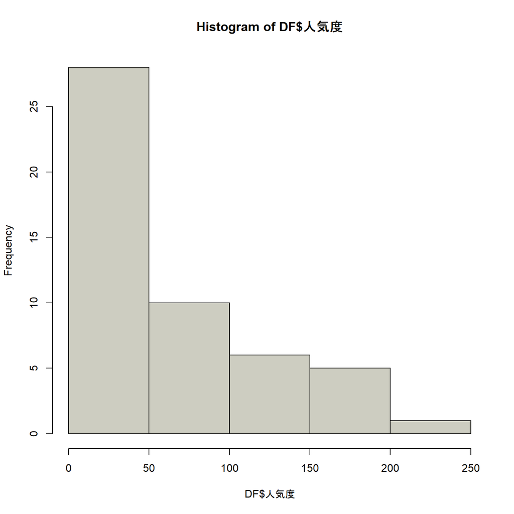

```r
#分布の確認
hist(DF$人気度,      col="ivory3")
```

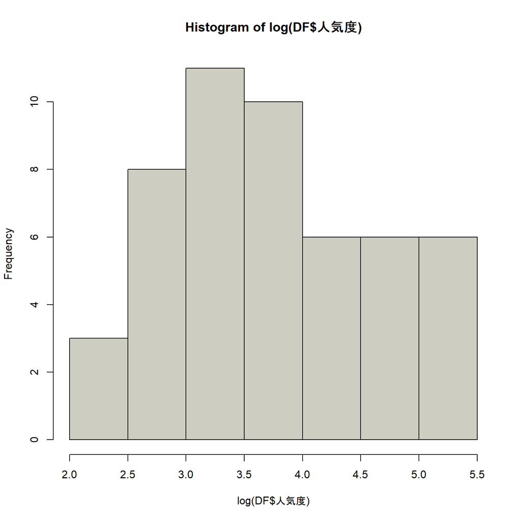

```r
#偏っているので、対数をとる
hist(log(DF$人気度), col="ivory3")
```

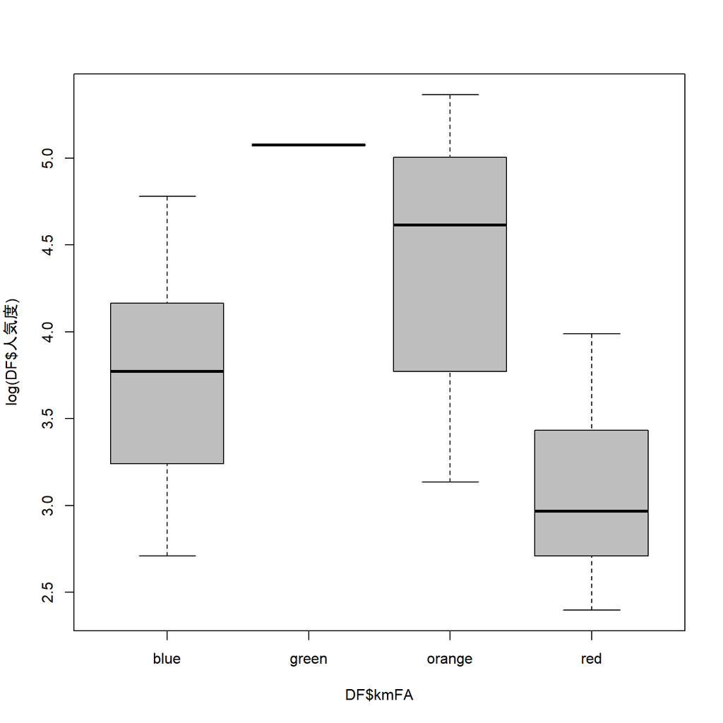

```r
#クラスタごとの人気度の分布
boxplot(log(DF$人気度) ~ DF$kmFA, col="grey")
```

### 回帰分析（因子を使わないパターン）

- Estimate:パラメータの推定値
- p-value:モデルの有意確率（モデル全体について） 5%以上だと×
- t value:パラメータの推定値を標準誤差で割ったもの。
- Pr(>|t|):パラメータ毎の有意確率（本当は0なのに偶然値が出た確率。5%以上だと×）
- あてはまりは良いが、有意なパラメータは「ゴミリサイクル率」のみ→過適合や多重共線性の疑い

```r
Lm1 <- lm(log(人気度) ~ ., data=DF[, c(3:28)])
summary(Lm1,digits = 2)
```

```
##
## Call:
## lm(formula = log(人気度) ~ ., data = DF[, c(3:28)])
##
## Residuals:
##      Min       1Q   Median       3Q      Max
## -0.60277 -0.13619  0.00777  0.12467  0.56727
##
## Coefficients:
##                                      Estimate Std. Error t value Pr(>|t|)
## (Intercept)                        -1.408e+03  1.569e+03  -0.898  0.37832
## 世帯あたり人数                     -2.532e+00  1.630e+00  -1.554  0.13336
## 年齢15未満比率                      7.092e+00  1.443e+01   0.491  0.62763
## 年齢65以上比率                     -1.678e+00  1.087e+01  -0.154  0.87855
## 転入者_対人口比                     9.518e-01  2.235e+01   0.043  0.96639
## 転出者_対人口比                     1.418e+01  2.728e+01   0.520  0.60790
## 昼間人口比_per                      1.929e-03  1.942e-03   0.993  0.33051
## 高齢単身世帯比率                   -4.455e+00  1.340e+01  -0.332  0.74245
## 第1次産業従業者数比                 1.297e+03  1.593e+03   0.814  0.42356
## 第2次産業従業者数比                 1.415e+03  1.568e+03   0.902  0.37601
## 第3次産業従業者数比                 1.416e+03  1.568e+03   0.903  0.37551
## 可住地面積比率                     -6.632e-01  7.389e-01  -0.898  0.37833
## 耕地面積_対可住面積比              -2.334e-01  2.189e+00  -0.107  0.91596
## 課税所得_就業者1人あたり_千円       3.493e-05  1.047e-04   0.334  0.74144
## 小売業販売額_事業所あたり_百万円    1.109e-03  1.984e-03   0.559  0.58145
## 小売業販売額_売場面積あたり_万円m2 -2.282e-03  5.210e-03  -0.438  0.66523
## 国民健保一人あたり診療費_円         7.340e-06  8.593e-06   0.854  0.40148
## ごみリサイクル率_pct               -2.922e-02  9.830e-03  -2.973  0.00662 **
## 千人あたり事業所数                 -2.546e-03  1.083e-02  -0.235  0.81610
## 千人あたり幼稚園数                  2.685e-01  3.265e+00   0.082  0.93514
## 千人あたり飲食店数                 -6.601e-03  6.039e-02  -0.109  0.91387
## 千人あたり大型小売店数             -1.874e+00  2.092e+00  -0.896  0.37926
## 千人あたり病院数                   -2.905e+00  3.407e+00  -0.853  0.40221
## 千人あたり老人ホーム数              2.385e+00  3.670e+00   0.650  0.52193
## 千人あたり交通事故発生件数          1.135e-01  8.522e-02   1.332  0.19524
## 千人あたり刑法犯認知件数           -5.651e-03  1.891e-02  -0.299  0.76771
## ---
## Signif. codes:  0 '***' 0.001 '**' 0.01 '*' 0.05 '.' 0.1 ' ' 1
##
## Residual standard error: 0.3286 on 24 degrees of freedom
## Multiple R-squared:  0.9284, Adjusted R-squared:  0.8538
## F-statistic: 12.45 on 25 and 24 DF,  p-value: 1.595e-08
```

多重共線性の確認 - 変数が他の変数で説明できるか？の指標

```r
#VIFは10を超えていると相関が高すぎる＝多重共線性が発生しているとされる
car::vif(Lm1)
```

```
##                     世帯あたり人数                     年齢15未満比率
##                       8.865640e+01                       3.745960e+01
##                     年齢65以上比率                    転入者_対人口比
##                       1.911331e+01                       1.320354e+02
##                    転出者_対人口比                     昼間人口比_per
##                       9.423737e+01                       1.006671e+02
##                   高齢単身世帯比率                第1次産業従業者数比
##                       1.442162e+01                       7.027825e+02
##                第2次産業従業者数比                第3次産業従業者数比
##                       6.122394e+06                       6.157580e+06
##                     可住地面積比率              耕地面積_対可住面積比
##                       4.632800e+00                       6.407427e+00
##      課税所得_就業者1人あたり_千円   小売業販売額_事業所あたり_百万円
##                       2.925883e+01                       1.874163e+01
## 小売業販売額_売場面積あたり_万円m2        国民健保一人あたり診療費_円
##                       4.046214e+01                       4.680362e+00
##               ごみリサイクル率_pct                 千人あたり事業所数
##                       4.847675e+00                       6.723542e+02
##                 千人あたり幼稚園数                 千人あたり飲食店数
##                       5.642512e+00                       2.618992e+02
##             千人あたり大型小売店数                   千人あたり病院数
##                       1.608345e+02                       1.123531e+01
##             千人あたり老人ホーム数         千人あたり交通事故発生件数
##                       7.919866e+00                       5.166385e+01
##           千人あたり刑法犯認知件数
##                       2.698357e+01
```

### 因子得点を使った回帰分析（因子得点のみを説明変数に使う）

- すべての説明変数が有意(Prが5%未満)
- 都会生活度の回帰係数が最も大きく、人気度に影響する

```r
Lm2 <- lm(log(人気度) ~ ., data=DF[, c(3, 29:31)])
summary(Lm2)
```

```
##
## Call:
## lm(formula = log(人気度) ~ ., data = DF[, c(3, 29:31)])
##
## Residuals:
##      Min       1Q   Median       3Q      Max
## -0.85951 -0.26045 -0.04873  0.28893  0.98545
##
## Coefficients:
##             Estimate Std. Error t value Pr(>|t|)
## (Intercept)  3.75975    0.05592  67.232  < 2e-16 ***
## ビジネス度   0.21442    0.05663   3.786 0.000441 ***
## 都会生活度   0.67448    0.05696  11.841 1.45e-15 ***
## 非高齢化度   0.31303    0.05757   5.437 2.00e-06 ***
## ---
## Signif. codes:  0 '***' 0.001 '**' 0.01 '*' 0.05 '.' 0.1 ' ' 1
##
## Residual standard error: 0.3954 on 46 degrees of freedom
## Multiple R-squared:  0.8012, Adjusted R-squared:  0.7882
## F-statistic: 61.79 on 3 and 46 DF,  p-value: 3.619e-16
```

```r
#標準偏回帰係数βを算出
require(lm.beta)          #βを算出するライブラリ
Lm2beta <- lm.beta(Lm2)   #関数lm.beta()でβを計算
summary(Lm2beta)
```

```
##
## Call:
## lm(formula = log(人気度) ~ ., data = DF[, c(3, 29:31)])
##
## Residuals:
##      Min       1Q   Median       3Q      Max
## -0.85951 -0.26045 -0.04873  0.28893  0.98545
##
## Coefficients:
##             Estimate Standardized Std. Error t value Pr(>|t|)
## (Intercept)  3.75975      0.00000    0.05592  67.232  < 2e-16 ***
## ビジネス度   0.21442      0.24893    0.05663   3.786 0.000441 ***
## 都会生活度   0.67448      0.77847    0.05696  11.841 1.45e-15 ***
## 非高齢化度   0.31303      0.35747    0.05757   5.437 2.00e-06 ***
## ---
## Signif. codes:  0 '***' 0.001 '**' 0.01 '*' 0.05 '.' 0.1 ' ' 1
##
## Residual standard error: 0.3954 on 46 degrees of freedom
## Multiple R-squared:  0.8012, Adjusted R-squared:  0.7882
## F-statistic: 61.79 on 3 and 46 DF,  p-value: 3.619e-16
```

```r
#多重共線性の確認（相関のない因子を抽出したため1となる）
vif(Lm2)
```

```
## ビジネス度 都会生活度 非高齢化度
##   1.000049   1.000040   1.000071
```

### Lm2による人気度予測結果（理論的な推定値）

```r
pred <- predict(Lm2, newdata=DF)
#結果は対数化されているので、指数化して戻す
exp(pred)
```

```
##   千代田区     中央区       港区     新宿区     文京区     台東区     墨田区
##  154.95439  164.01760  159.89420  149.67378  102.34478   86.47239   57.86280
##     江東区     品川区     目黒区     大田区   世田谷区     渋谷区     中野区
##   44.36819   83.17250  111.51324   46.72621   63.82924  186.01241  132.73331
##     杉並区     豊島区       北区     荒川区     板橋区     練馬区     足立区
##   97.67449  119.45859   62.88663   42.20966   49.08466   40.13184   25.49046
##     葛飾区   江戸川区   八王子市     立川市   武蔵野市     三鷹市     青梅市
##   26.41777   27.81339   18.42797   35.93103   76.50523   53.07291   10.39808
##     府中市     昭島市     調布市     町田市   小金井市     小平市     日野市
##   33.96844   22.52521   49.44897   19.57187   56.35178   31.41269   27.29629
##   東村山市   国分寺市     国立市     福生市     狛江市   東大和市     清瀬市
##   20.33504   51.33878   47.41775   29.97468   54.32592   19.81003   20.68030
## 東久留米市 武蔵村山市     多摩市     稲城市     羽村市 あきる野市   西東京市
##   21.78108   15.04395   24.20883   21.72483   19.03246   10.43447   31.35419
##     瑞穂町
##   11.46830
```

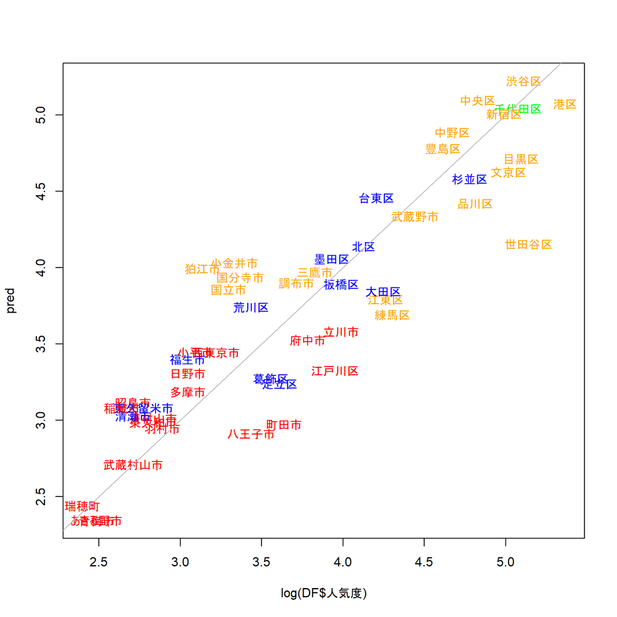

```r
#実測値と理論上の推定値
plot(log(DF$人気度), pred, type="n")
text(log(DF$人気度), pred, DF$市町村, col=color.kmFA)
lines(c(0, 10), c(0, 10), col="grey")
```